# Lab 04 - Data Visualization and GAMs

```python
#%pip install pygam
#%pip install folium
import pandas as pd
import numpy as np
from plotnine import *
import warnings
warnings.filterwarnings('ignore')
import matplotlib.pyplot as plt
from pygam import LinearGAM, s
import statsmodels.api as sm
from folium.plugins import MarkerCluster
```

# Learning Goals

- Read in and prepare the meteorological dataset
- Use `pd.merge()` to join two datasets
- Deal with missings and impute data
- Create several graphs with different `geoms` in `plotnine`
- Create a facet graph
- Conduct customizations of the graphs
- Fit smooth regression models using `pygam` and compare to a linear regression model

# Lab Description

We will work with the meteorological data from last week’s lab.

**The objective of the lab is to examine the association between weather variables in the US, practice data visualization, and fit smooth regression models.**

### 1. Read in the data

First download and then read in with pandas:

```python
url = "https://raw.githubusercontent.com/JSC370/JSC370-2026/main/data/met_all_2025.gz"
met = pd.read_csv(url, compression="gzip")
```

### 2. Prepare the data: some wrangling

- From last week: remove temperatures less than -20C and change 999.9 to NaN.
- Generate a date variable using `pd.to_datetime()`.
- Using date filtering, keep the observations of the first week of July 2025.
- Compute the mean by station of the variables `temp`, `rh`, `wind_sp`, `vis_dist`, `dew_point`, `lat`, `lon`, and `elev`.
- Create a region variable for NW, SW, NE, SE based on lon = -98.00 and lat = 39.71 degrees.
- Create a categorical variable for elevation (low: < 252m, high: >= 252m)

```python
# Replace 999.9 with NaN and filter temps > -20
met.loc[met['temp'] == 999.9, 'temp'] = np.nan
met = met[met['temp'] > -20].copy()

# Create date variable
met['date'] = pd.to_datetime(
    met[['year', 'month', 'day', 'hour']])

# Create region variable using np.select
met['region'] = (
    np.select(
        [
            (met['lon'] < -98) & (met['lat'] >= 39.71),
            (met['lon'] >= -98) & (met['lat'] >= 39.71),
            (met['lon'] < -98) & (met['lat'] < 39.71),
        ],
        ['NW', 'NE', 'SW'],
        default='SE'
    )
)

# Create elevation category
met['elev_high_low'] = np.select(
    [met['elev'] >= 252],
    ['high'],
    default='low'
)

display(met.head())
```

|  | USAFID | WBAN | year | month | day | hour | min | lat | lon | elev | ... | temp | temp_qc | dew_point | dew_point_qc | atm_press | atm_press_qc | rh | date | region | elev_high_low |
| --- | --- | --- | --- | --- | --- | --- | --- | --- | --- | --- | --- | --- | --- | --- | --- | --- | --- | --- | --- | --- | --- |
| 0 | 690150 | 93121 | 2025 | 6 | 1 | 0 | 26 | 34.296 | -116.162 | 625 | ... | 37.2 | 1 | 4.4 | 1 | NaN | 9 | 12.952344 | 2025-06-01 00:00:00 | SW | high |
| 1 | 690150 | 93121 | 2025 | 6 | 1 | 0 | 54 | 34.296 | -116.162 | 625 | ... | 36.7 | 1 | 4.4 | 1 | 1008.4 | 1 | 13.324572 | 2025-06-01 00:00:00 | SW | high |
| 2 | 690150 | 93121 | 2025 | 6 | 1 | 1 | 54 | 34.296 | -116.162 | 625 | ... | 34.4 | 1 | 4.4 | 1 | 1008.4 | 1 | 15.194316 | 2025-06-01 01:00:00 | SW | high |
| 3 | 690150 | 93121 | 2025 | 6 | 1 | 2 | 54 | 34.296 | -116.162 | 625 | ... | 32.2 | 1 | 5.6 | 1 | 1008.9 | 1 | 18.773303 | 2025-06-01 02:00:00 | SW | high |
| 4 | 690150 | 93121 | 2025 | 6 | 1 | 3 | 54 | 34.296 | -116.162 | 625 | ... | 31.1 | 1 | 5.6 | 1 | 1009.1 | 1 | 20.015403 | 2025-06-01 03:00:00 | SW | high |

5 rows × 33 columns

### 3. Use `geom_violin` to examine `dew_point` for low and high elevations by region

Use `geom_violin` and subset the data to the first two weeks in July.

- Subset to the first two weeks in July
- Use facets
- Summarize below

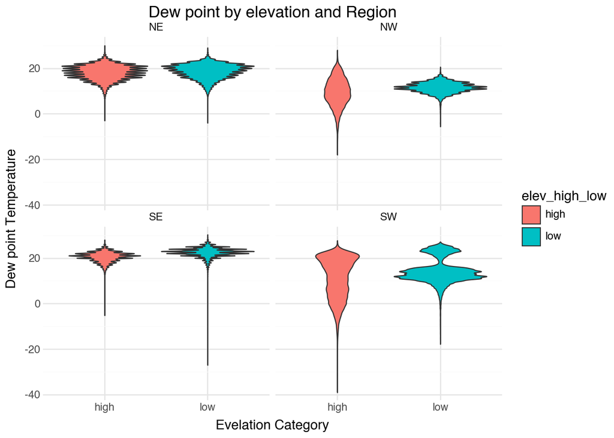

```python
# Subset to first two weeks of July
met_july = met[(met['date'] >= '2025-07-01') & (met['date'] < '2025-07-15')].copy()

# Create violin plot with facets
(ggplot(met_july,
        aes(x='elev_high_low', y='dew_point', fill='elev_high_low')) +
  geom_violin() +
  facet_wrap('~region') +
  labs(x='Evelation Category', y='Dew point Temperature',
       title='Dew point by elevation and Region') +
  theme_minimal())
```

Summary: - For NE and SE, the elevation has low effect on general. The dew point is dense around 20 for these two region. For NW and SW, evelation has higher impact. high elevation has more spread dew point, while low elevation has denser dew point. Apart from the effect of elevation, the region has high influence on the dew point, with SW and NW have lower dew point than NE and SE in general.

### 4. Use `geom_bar` to create barplots of the proportion of weather stations by elevation category colored by region

- Use the subset data from #3, the first two weeks of July
- Create nice labels on axes and add a title
- Try a second plot with counts and `dodge` positioning
- Summarize below

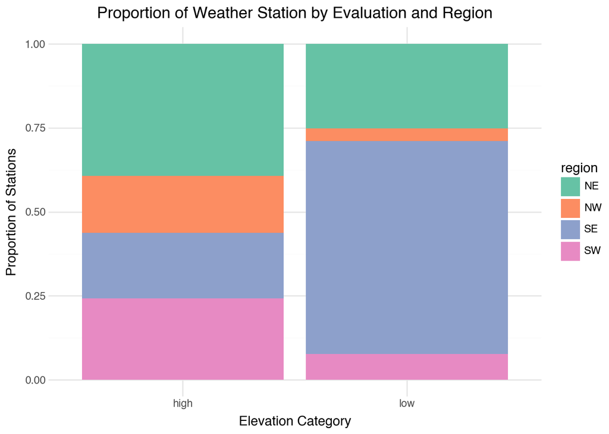

```python
# Proportion barplot (position='fill')
(ggplot(met_july,
        aes(x='elev_high_low', fill='region')) +
  geom_bar(position='fill') +
  scale_fill_brewer(type='qual', palette='Set2') +
  labs(x='Elevation Category', y='Proportion of Stations',
       title='Proportion of Weather Station by Evaluation and Region') +
  theme_minimal())
```

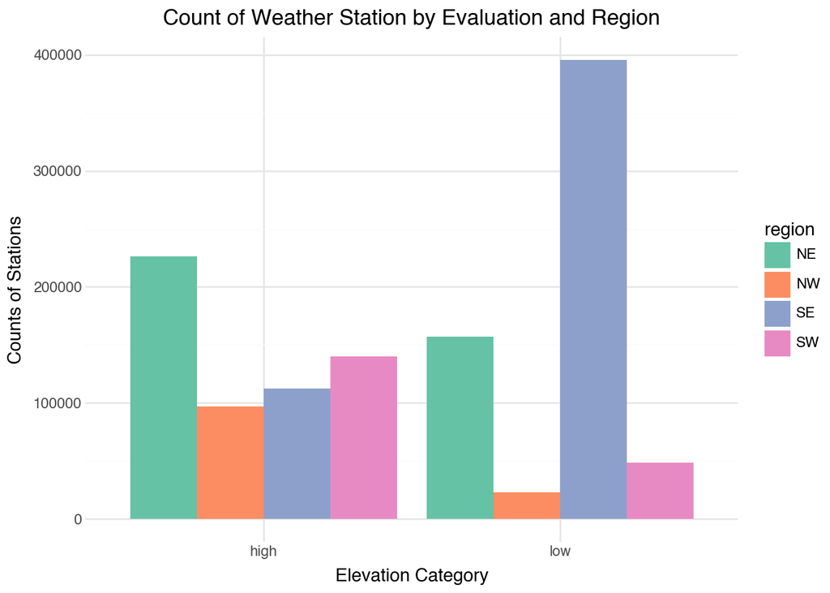

```python
# Count barplot with dodge positioning
(ggplot(met_july,
        aes(x='elev_high_low', fill='region')) +
  geom_bar(position='dodge') +
  scale_fill_brewer(type='qual', palette='Set2') +
  labs(x='Elevation Category', y='Counts of Stations',
       title='Count of Weather Station by Evaluation and Region') +
  theme_minimal())
```

### 5. Use `stat_summary` to examine mean dew point by region with standard deviation error bars

- Use `stat_summary` with appropriate functions for mean and standard deviation
- Add error bars using another layer of `stat_summary` with `geom = "errorbar"`
- Use `coord_flip`
- Add labels and a title
- Summarize below

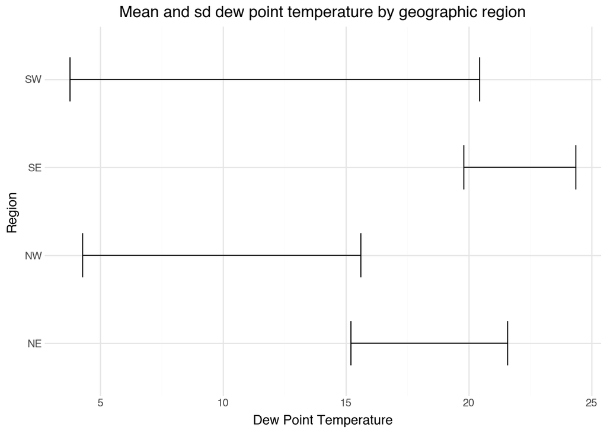

```python
# Use stat_summary with fun_y, fun_ymin, fun_ymax
# Hint: fun_ymin=lambda x: np.mean(x) - np.std(x)

(ggplot(met_july, aes(x='region', y='dew_point')) +
  stat_summary(fun_y=np.mean,
               fun_ymin=lambda x: np.mean(x) - np.std(x),
               fun_ymax=lambda x: np.mean(x) + np.std(x),
               geom='errorbar') +
  coord_flip() +
  labs(x='Region', y='Dew Point Temperature',
       title='Mean and sd dew point temperature by geographic region') +
  theme_minimal())
```

Summary: - Similar as what we saw in the faceted volin plot before, NE and SE have generally higher dew point with lower spread (variance), whereas SW and NW have lower dew point on avergae but vary lot.

### 6. Smooth Regression with GAMs

Let’s practice running regression models with smooth functions on X. We use the `statsmodels` OLS for linear models and `pygam` package and `LinearGAM` function to do this.

- Use the subsetted data. First remove NaN before fitting
- Fit both a linear model with `sm.OLS` and a spline model (use `LinearGAM()` with `s()` for a smooth term on wind_sp and temp).
- For the spline model try `n_splines` = 20
- Summarize and plot the results from the models.

```python
# Data prep
# Remove NaN values before fitting
met_clean = met_july.dropna(subset=['wind_sp', 'temp', 'dew_point'])

X = met_clean[['wind_sp', 'temp']].values
y = met_clean['dew_point'].values
```

- Now fit linear model with sm.OLS

```python
# Don't forget to add a constant
X_const = sm.add_constant(X)

linear_mod = sm.OLS(y, X_const).fit()
print("Linear Model:")
print(linear_mod.summary())
```

```
Linear Model:
                            OLS Regression Results
==============================================================================
Dep. Variable:                      y   R-squared:                       0.115
Model:                            OLS   Adj. R-squared:                  0.115
Method:                 Least Squares   F-statistic:                 7.655e+04
Date:                Wed, 28 Jan 2026   Prob (F-statistic):               0.00
Time:                        15:36:13   Log-Likelihood:            -3.7478e+06
No. Observations:             1179052   AIC:                         7.496e+06
Df Residuals:                 1179049   BIC:                         7.496e+06
Df Model:                           2
Covariance Type:            nonrobust
==============================================================================
                 coef    std err          t      P>|t|      [0.025      0.975]
------------------------------------------------------------------------------
const         10.5146      0.025    416.774      0.000      10.465      10.564
x1            -0.6365      0.003   -247.137      0.000      -0.642      -0.631
x2             0.3780      0.001    360.631      0.000       0.376       0.380
==============================================================================
Omnibus:                   476811.128   Durbin-Watson:                   0.041
Prob(Omnibus):                  0.000   Jarque-Bera (JB):          2155439.708
Skew:                          -1.970   Prob(JB):                         0.00
Kurtosis:                       8.324   Cond. No.                         119.
==============================================================================

Notes:
[1] Standard Errors assume that the covariance matrix of the errors is correctly specified.
```

Summary:

- Report adjusted R2
- Are the beta coefficients for wind speed and temperature significant?
- the adjusted R-square is 0.115 about 11.5% of the variation is explained by the model
- both ceofficients have 0.000 p-value, under almost any common threshold, say 0.05, they are considered significant.

```python
# GAM spline model
# Use LinearGAM with s() for smooth terms
# s(0) refers to first column, s(1) to second column

gam_mod = LinearGAM(
    s(0, n_splines=20) +
    s(1, n_splines=20)).fit(X, y)
print("\nSmooth Spline Model:")
print(gam_mod.summary())
```

```
Smooth Spline Model:
LinearGAM
=============================================== ==========================================================
Distribution:                        NormalDist Effective DoF:                                     30.3714
Link Function:                     IdentityLink Log Likelihood:                              -3620561.7191
Number of Samples:                      1179052 AIC:                                          7241186.1811
                                                AICc:                                         7241186.1828
                                                GCV:                                               27.2124
                                                Scale:                                              5.2164
                                                Pseudo R-Squared:                                   0.2868
==========================================================================================================
Feature Function                  Lambda               Rank         EDoF         P > x        Sig. Code
================================= ==================== ============ ============ ============ ============
s(0)                              [0.6]                20           13.5         1.11e-16     ***
s(1)                              [0.6]                20           16.9         1.11e-16     ***
intercept                                              1            0.0          1.11e-16     ***
==========================================================================================================
Significance codes:  0 '***' 0.001 '**' 0.01 '*' 0.05 '.' 0.1 ' ' 1

WARNING: Fitting splines and a linear function to a feature introduces a model identifiability problem
         which can cause p-values to appear significant when they are not.

WARNING: p-values calculated in this manner behave correctly for un-penalized models or models with
         known smoothing parameters, but when smoothing parameters have been estimated, the p-values
         are typically lower than they should be, meaning that the tests reject the null too readily.
None
```

Summary:

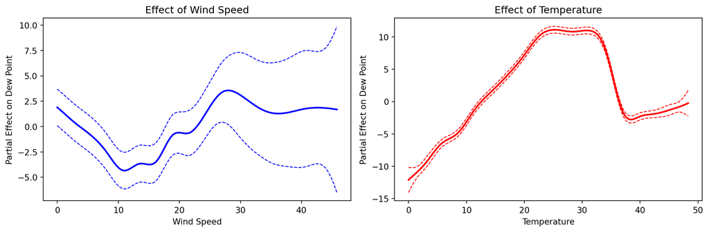

```python
# Plot partial dependence curves for each predictor

# define the figure size
fig, axes = plt.subplots(1, 2, figsize=(12, 4))

# define the variables and colors
spec = [
    (0, 0, "Wind Speed",  "blue", "Effect of Wind Speed"),
    (1, 1, "Temperature", "red",  "Effect of Temperature"),
]

# loop over smooth variables
for ax, (term, xcol, xlabel, color, title) in zip(axes, spec):
    XX = gam_mod.generate_X_grid(term=term)
    x = XX[:, xcol]
    pd_effect = gam_mod.partial_dependence(term=term, X=XX)
    _, ci = gam_mod.partial_dependence(term=term, X=XX, width=0.95)

    ax.plot(x, pd_effect, color=color, lw=2)
    ax.plot(x, ci, color=color, ls="--", lw=1)
    ax.set(xlabel=xlabel, ylabel="Partial Effect on Dew Point", title=title)

plt.tight_layout()
plt.show()
```

Summary:

- Visual inspection of the fitted curves
- Does the smooth term capture meaningful non-linearity?
- Visual inspection: both curve are non-linear, the effect of wind speed is more spread out for high wind speed, while that of temperature is more tighten.
- The smooth term does capture meaningful non-linearity according to the Pseduo R-square. Intuitively, the shape of both curve are significantly non-linear, so the non-linearity is captured by the model.